# Session 3 - Daten einlesen

15. Mai 2018

## Syllabus

Session 1 - R and RStudio

Session 2 - Data Typen und erste Befehle

`Session 3 - Daten einlesen und speichern`

Session 4 - Einfache Analyse (numerisch)

Session 5 - Visualisierung

Session 6 - Application Programming Interfaces (APIs)

Session 7 - Introduction to Text Mining

Session 8 & 9 - Web Scraping

## Agenda

## Agenda

1. Recap
2. Datenformate einlesen
3. Daten zusammenführen
4. Datensatz speichern
5. Pfade
6. Aufgaben

## Hausaufgaben besprechen

## 1. Recap

Lade den Datensatz `gtdb_data_types.Rdata`.

1. Speicher `attack_type` in **Uppercase** in der Variable `attack_upper`.
2. Kombiniere `date` und `n_kill` zu einem neuen Vektor `nonsense`. Wie lang ist der Vektor?
3. Wieviele Tote gab es durchschnittlich?

## 2. Datenformate einlesen

## Comma Seperated Values (CSV) (1)

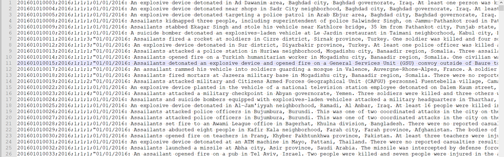

## Comma Seperated Values (CSV) (2)

- jede Zeile in der Datei entspricht einer Zeile im Datensatz
- Spalten werden mit Hilfe eines sogenannten Seperators/Delimiter getrennt (Komma, Semicolon)

## Comma Seperated Values (CSV) (3)

```r
# csv getrennt durch Komma
my_komma_csv <- read_csv("komma_csv.csv")
```

```r
# csv getrennt durch Semicolon
my_semicolon_csv <- read_csv("my_csv.csv",
                             delim = ";")
```

## Tab Seperated Values (TSV) (1)

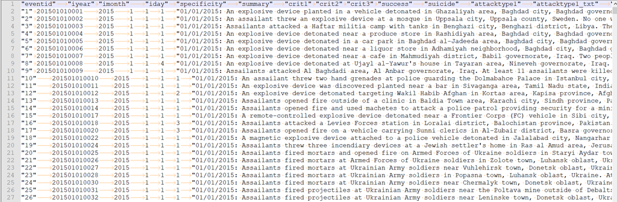

## Tab Seperated Values (TSV) (2)

- jede Zeile in der Datei entspricht einer Zeile im Datensatz
- Spalten werden mit Hilfe eines sogenannten Seperators/Delimiter getrennt (Tabulator)

```r
# tab als Delimiter
my_tsv <- read_csv("komma_csv.csv",
                   delim = "\t")
```

## Excel (xls & xlsx) (1)

[figure not shown]

## Excel (xls & xlsx) (2)

```r
# Laden des Pakets "readxl"
library(readxl)

# xlsx
my_xlsx <- read_excel("my_xlsx.xlsx")
```

## RData

- Bereits letzte Sitzung kennengelernt
- Laden ins Enviroment mit …

```r
# Laden einer kompletten R Session
my_RData <- load("myData.RData")

# Laden einer einzelnen Variable/Objekt
my_RObject <- readRDS("myData.rds")
```

## 3. Daten zusammenführen

## R(ow)-bind (1)

- Verknüpft zwei Dataframes entlang ihrer Zeilen

```r
df1
```

```
##       Stadt      Land Fluss
## 1  Konstanz Kolumbien Kongo
## 2 Stuttgart   Schweiz Seine
## 3     Essen   Estland  Elbe
```

```r
df2
```

```
##     Stadt  Land  Fluss
## 1 München  Mali Moldau
## 2 Hamburg Haiti  Havel
```

## R(ow)-bind (2)

```r
df_rbind <- rbind(df1, df2)
df_rbind
```

```
##       Stadt      Land  Fluss
## 1  Konstanz Kolumbien  Kongo
## 2 Stuttgart   Schweiz  Seine
## 3     Essen   Estland   Elbe
## 4   München      Mali Moldau
## 5   Hamburg     Haiti  Havel
```

## C(olum)-bind (1)

- Verknüpft zwei Dataframes entlang ihrer Spalten

```r
df3
```

```
##     Name  Tier            Beruf
## 1  Kevin   Kuh             Koch
## 2 Sabine Schaf Schriftstellerin
## 3 Eduard  Esel         Erzieher
## 4   Mike  Möwe           Maurer
## 5  Heidi  Hund       Headhunter
```

## C(olum)-bind (2)

```r
df_cbind <-  cbind(df_rbind,df3)
df_cbind
```

```
##       Stadt      Land  Fluss   Name  Tier            Beruf
## 1  Konstanz Kolumbien  Kongo  Kevin   Kuh             Koch
## 2 Stuttgart   Schweiz  Seine Sabine Schaf Schriftstellerin
## 3     Essen   Estland   Elbe Eduard  Esel         Erzieher
## 4   München      Mali Moldau   Mike  Möwe           Maurer
## 5   Hamburg     Haiti  Havel  Heidi  Hund       Headhunter
```

## Merging (1)

- Verknüpfung von zwei Datensätzen mittels einer oder mehrerer Variablen

```r
df_purchase
```

```
##   Customer_ID Product Price
## 1           1  Tablet   249
## 2           1   Phone   760
## 3           2  Laptop  1200
## 4           3   Clock   300
```

```r
df_income
```

```
##   Customer_ID Income
## 1           2   3600
## 2           3    750
## 3           1   1200
## 4           4   1800
```

## Merging (2)

```r
# merge two datasets
transparent_customer <- merge(df_purchase, df_income,
                              by = "Customer_ID")


transparent_customer
```

```
##   Customer_ID Product Price Income
## 1           1  Tablet   249   1200
## 2           1   Phone   760   1200
## 3           2  Laptop  1200   3600
## 4           3   Clock   300    750
```

## 4. Daten Speichern

- Best Practise: CSV als Export

```r
write_csv(my_test_data,
          file = "my_test_data.csv",
          delim = "$")
```

- alternativ als RData oder rds

```r
save(my_test_data,
     file = "my_test_data.RData")

saveRDS(my_test_Object,
     file = "my_test_object.rds")
```

### Absoluter Pfad

- die Pfadangabe erfolgt ausgehend vom Stammverzeichnis (Root)

```r
C:/Users/JohnDoe/Dokumente/Rkurs/Data/Session_3
```

### Relativer Pfad

- die Pfadangabe erfolgt ausgehend vom aktuellen Verzeichnis

```r
./Data/Session_3
```

## Pfade (2)

- **Windows-NutzerInnen**: Pfade müssen angepasst werden \(\rightarrow\) Backslash durch Forwardslash ersetzen

```r
C:/Users/JohnDoe/Dokumente/Rkurs/Data/Session_3

statt

C:\Users\JohnDoe\Dokumente\Rkurs\Data\Session_3
```

- innerhalb unseres R-Projekts geben wir stets relative Pfade an
- Pfade werden immer relativ zum Ordner des Projektes angegeben
- erlaubt und vereinfacht Replizierbarkeit des Codes auf anderen Systemen/Ordnern

## 5. Aufgaben

1. Inspiziere die unterschiedlichen Dateien des Ordners `./Data/Session_3`.
2. Lade alle Dateien in R und speicher sie in unterschiedlichen, aussagekräftigen Variablen.
3. Schaue dir die Variablen mit Hilfe des Befehls `View()` an.
4. Füge die vier Teildatensätze sinnvoll zusammen. Überlege sorgfältig, welche der kennengelernten Funktionen du dabei benötigst und welche nicht.
5. Speicher den finalen Datensatz im rds-Format in deinem Projektordner unter `/data/gtdb.RDS`.